# Effects of UV light on pigment retention in Adirondack copepods (*Aglaodiaptomus* *leptopus*)

Anna

11/30/2022

## Introduction

This semester I have been working in the Baldwin lab studying copepods (*A. leptopus*) from a bog in the northern Adirondacks near Sevey’s Point, NY. Past research shows that throughout the year, the copepods in this bog experience a change in pigment color. In the Spring they display red pigment and the color shifts to blue during the Summer months before returning to a red color in the Fall. My research explores what the driving force may be behind this pigment change and why. There are a few pre-cursors that are known to have effects on animal pigmentation which include diet, temperature changes, and UV light exposure. One that we are all familiar with is the effect that UV radiation has on our own skin. In the summer when UV radiation is most intense, it is common for our skin to become more tan due to increased melanin production. This fact is well-researched in humans, but with my research I wanted to examine if UV was also the driver of pigment change in these copepods.

## Experimental Process

After collecting my copepod specimens from the bog, I anesthetized and photographed them under a microscope. I then imported those photos into Photoshop and recorded an average of the total body color of each specimen. In Photoshop, a color contains three values: **L**, **a**, and **b** which represent **luminosity**, the **red** vs. **green** scale, and the **blue** vs. **yellow** scale, respectively. After recording these initial values, I leave the zoopl. under different light treatments for 7 days and record how their pigment changes over the course of the week.

## Preliminary Steps

Before diving into my research, I need to upload the necessary R packages, import my data, and tidy up my data so that it is ready for analysis.

### Setting things up

Here, I am clearing R’s brain so that I am starting with a clean slate before writing any code. I am also uploading the `tidyverse`, `ggfortify`, and `here` packages in anticipation of manipulating and modeling my data.

```r
rm(list=ls())
library(here)
library(tidyverse)
library(ggfortify)
```

### Importing My Data

Conveniently, as I started Biostats this semester I was also starting my SYE project, so while I was collecting data for it, I was being conscious of how I set up my data in Excel. I used data validation to decrease my chances of having errors in my data, made sure to name my column headers without spaces or special characters, and entered only one variable per cell.

This is the data set I used:

```r
DF <- read.csv(here("Data", "cap_color_data_final.csv"), stringsAsFactors = TRUE)
```

I decided to use `stringsAsFactors = TRUE` because I want to convert the character strings into factors that can be easily grouped and filtered for analysis and data visualization.

Included in the `Data` folder of the project is a metadata document describing the significance of each of the variables in this data set.

It’s a good idea to take a look at the variables within the data frame first to see what data I am working with and to double check that the character strings were successfully converted to factor variables.

```r
str(DF)
```

```
## 'data.frame':    706 obs. of  10 variables:
##  $ image_name         : Factor w/ 313 levels "14Oct_D1a","14Oct_D1b",..: 103 104 105 106 107 108 109 110 111 111 ...
##  $ L                  : int  64 63 62 66 64 77 74 66 68 80 ...
##  $ a                  : int  2 2 2 6 2 3 6 3 2 2 ...
##  $ b                  : int  -1 -1 -1 8 -3 4 7 2 1 4 ...
##  $ treatment          : Factor w/ 3 levels "D","NL","UV": 1 1 1 1 1 1 1 1 1 1 ...
##  $ rep                : int  1 1 1 1 1 1 1 1 1 1 ...
##  $ before_after       : Factor w/ 2 levels "after","before": 1 1 1 1 1 1 1 1 1 1 ...
##  $ date_collected     : Factor w/ 4 levels "10/14/22","10/20/22",..: 4 4 4 4 4 4 4 4 4 4 ...
##  $ trial_duration_days: int  7 7 7 7 7 7 7 7 7 7 ...
##  $ date_photo         : Factor w/ 7 levels "10/12/22","10/13/22",..: 1 1 1 1 1 1 1 1 1 1 ...
```

## Analysis

While analyzing my dating, I will be operating with the following workflow:

`Plot > Guess relationships > Create model > Guess model assumptions > Run/interpret model > Replot to show key relationships`

### Hypothesis 1: Pigmentation fades after 7 days in darkness and natural light treatments, and therefore the luminosity value significantly increases during this period.

To test this, I will first make a quick plot to get an idea of the spread of data and identify possible trends. I will start by creating a data frame that includes the desired variables. As I drafted my experiment, the design changed week to week, which is why I am selecting only the data from samples collected on 10/14/22. For these data, I collected before and after images for both NL and D treatments.

```r
luminosity <- DF[, c("L", "treatment", "before_after", "date_collected")] %>%
  filter(DF$date_collected == "10/14/22")
```

Before moving forward, I will look at a summary of the data to ensure there is nothing funky happening with my data.

```r
summary(luminosity)
```

```
##        L         treatment before_after  date_collected
##  Min.   :46.00   D :78     after :115   10/14/22:155
##  1st Qu.:57.00   NL:77     before: 40   10/20/22:  0
##  Median :61.00   UV: 0                  11/3/22 :  0
##  Mean   :60.31                          9/29/22 :  0
##  3rd Qu.:64.00
##  Max.   :75.00
```

Looking at the spread of luminosity (L) values, they are what I would expect. After working on color analysis all semester, I can confidently say that most L-values for my copepod images fall in the range of about 45 to 80.

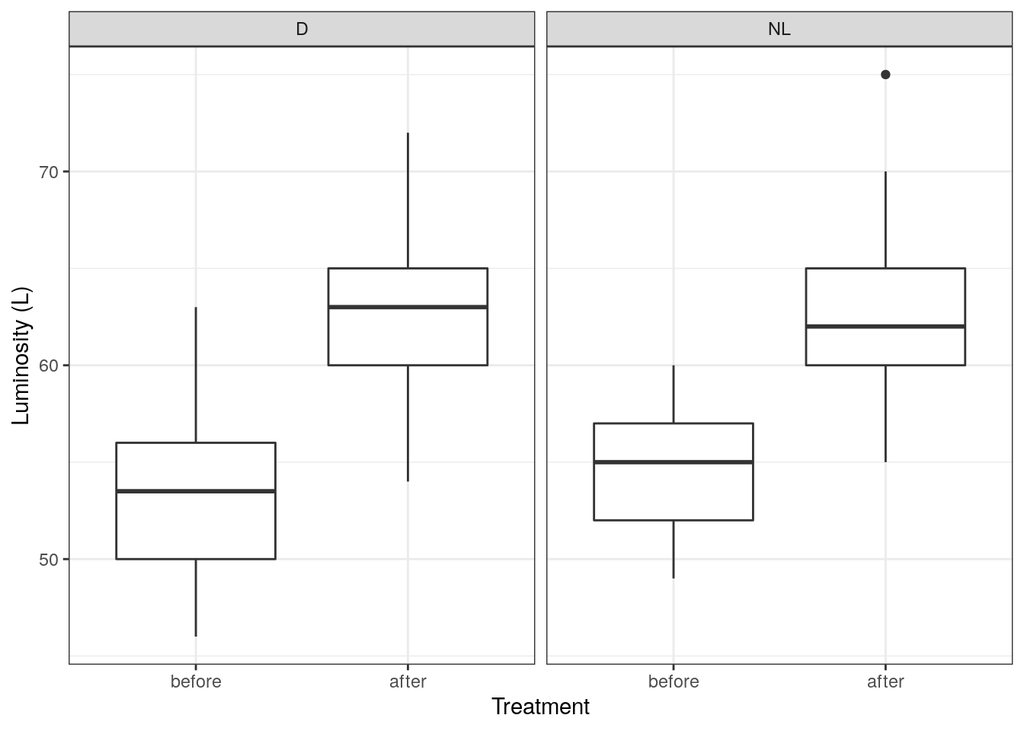

```r
ggplot(luminosity, aes(x = before_after, y = L)) +
geom_boxplot() +
xlab("Treatment") +
ylab("Luminosity (L)") +
theme_bw() +
facet_wrap(~treatment) +
scale_x_discrete(limits = c("before", "after"))
```

By looking at this plot, it seems that luminosity values for darkness (D) and natural light (NL) treatments were fairly similar. For D, the average luminosity of the copepod pigmentation before the experiment seems to be at about 54, and after they were in darkness for 7 days, the average L-value was at about 63. For NL, the L-value changed from about 55 to 62 under natural light. Based on these observations, I am guessing that for both D and NL treatments, luminosity changed significantly after 7 days, but the two treatments themselves did not effect luminosity differently. In other words, the pigment faded under both treatments, but one light treatment did not cause the pigment to fade significantly more than the other.

To check if this is statistically true, I will make a statistical model. I am choosing to use a *generalized* linear model because L-values are integer valued and are bound on a scale from 0-100. Therefore, a *general* linear model would not be appropriate because normal distribution cannot be assumed.

```r
model_L <- glm(L ~ treatment * before_after, data = luminosity, family = poisson)
```

A few important thinsg to note about my glm…

1. I have made L a function of `treatment * before_after` to test the interaction between these two variables. Later on when I run the statistics, I will be able to see if the treatment affects the luminosity differently when comparing before and after values.
2. I have decided to set the family equal to `poisson` because the L-scale on the y-axis is not continuous. As I mentioned before, the data are bounded by a scale, so the Poisson distribution accounts for this.

To ensure that the assumptions I am making about the distribution of my data are appropriate, I will use the autoplot function:

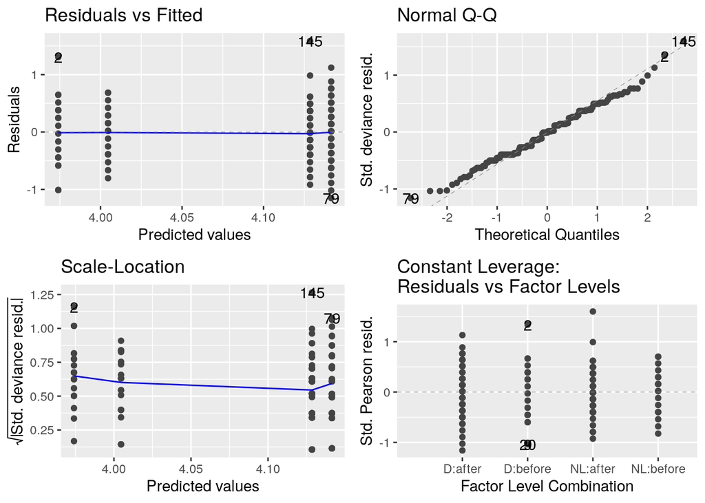

```r
autoplot(model_L, smooth.color = NA)
```

The residuals appear to be evenly distributed and the data points follow a normal distribution according to the Q-Q plot, so I can confirm that my assumptions were okay and I can move on to running my model.

```r
anova(model_L, test = "Chisq")
```

```
## Analysis of Deviance Table
##
## Model: poisson, link: log
##
## Response: L
##
## Terms added sequentially (first to last)
##
##
##                        Df Deviance Resid. Df Resid. Dev  Pr(>Chi)
## NULL                                     154     72.726
## treatment               1    0.026       153     72.700    0.8711
## before_after            1   36.154       152     36.546 1.824e-09 ***
## treatment:before_after  1    0.785       151     35.761    0.3755
## ---
## Signif. codes:  0 '***' 0.001 '**' 0.01 '*' 0.05 '.' 0.1 ' ' 1
```

There are a few conclusions I can make based on this model:

- The luminosity values between the D and NL treatments is not significantly different (p = 0.8711).
- For both treatments, luminosity of the copepods increased significantly after 7 days (p < 0.05).
- The light treatments did not affect the luminosity differently during the 7-day trial (p = 0.3755)

To visualize these findings and highlight the key relationships, I will create an interaction plot. The first step in this process is to create a separate data frame summarizing the mean values of luminosity for both treatments both before and after the 7-day period.

```r
sumDF_L <- luminosity %>%
  filter(date_collected == "10/14/22") %>%
  group_by(treatment, before_after) %>%
  summarize(meanL = mean(L),
            seL = sd(L)/sqrt(n())
              )
```

Once I have those mean values isolated, I can use them to create the interaction plot:

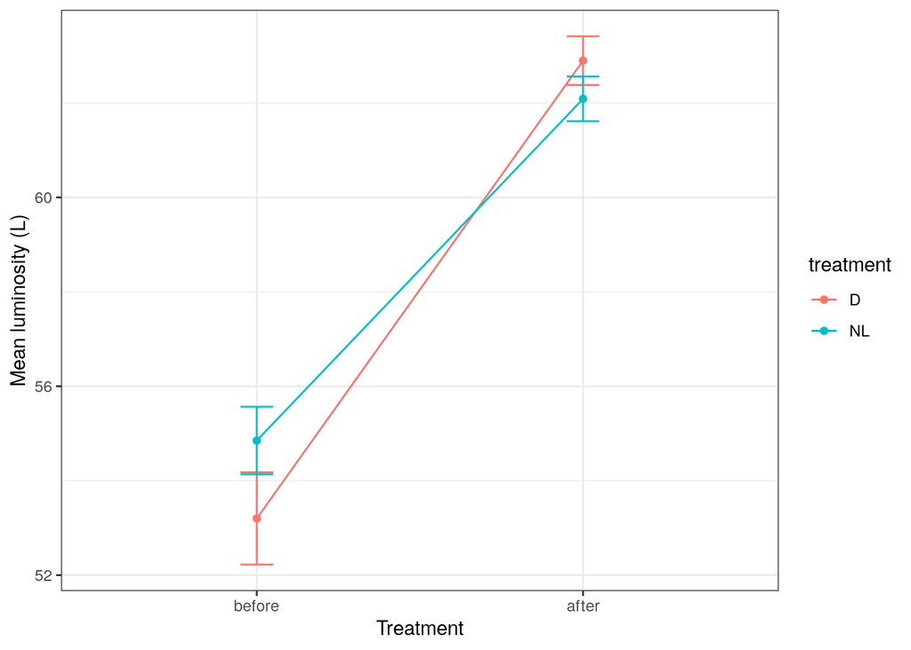

```r
ggplot(sumDF_L, aes(before_after, meanL, color = treatment, group = treatment)) +
  geom_point() +
  geom_line() +
  geom_errorbar(aes(ymin = meanL - seL,
                    ymax = meanL + seL), width = 0.1) +
  theme_bw() +
  scale_x_discrete(limits = c("before", "after")) +
  xlab("Treatment") +
  ylab("Mean luminosity (L)")
```

Typically on an interaction plot, intercepting lines indicate that there is a significant interaction between two factors. For example, looking at this plot, it may appear that the darkness treatment causes the copepods to become more luminous over time than the natural light treatment, but as we confirmed with our statistical model, that is not the case. The overlapping of the error bars for the two teatments also indicates to us that the slopes of these lines could be variable and therefore we cannot say that one treatment significantly affects luminosity differently than the other.

### Hypothesis 2: Darker pigmentation is retained when copepods are kept under UV light for 7 days, and therefore luminosity does not increase significantly.

Many people are familiar with the fact that our skin darkens when we are exposed to a certain amount UV radiation. This is caused by an increase in melanin triggered by the UV wavelengths and it is a form of natural photoprotection. My goal with this project was to explore how UV affects copepod pigmentation, and if an argument can be made that dark pigmentation is attributed to UV radiation for these animals as well.

On 11/3/22, I collected copepod samples at the bog and photographed them 24 hours later to allow them to acclimate to thte temperature in the lab. I analyzed these “before” images and will be referring to the L, a, and b values from this group as the `control` treatment. I then placed the copepods into three treatment groups: darkness (`D`), natural light (`NL`), and UV light (`UV`). After 7 days, I photographed these individuals and analyzed their color in order to compare them to the control.